# IODS course project

## 5.2 Principal component analysis (PCA)

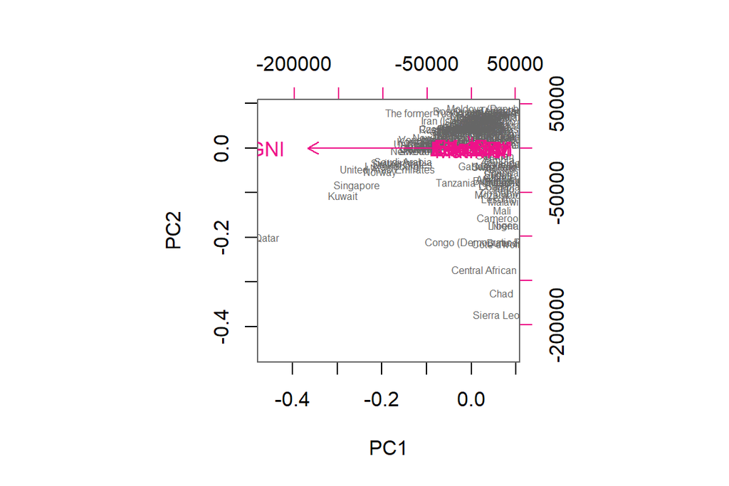

```r
#RAW data
# perform principal component analysis (with the SVD method) on the raw human data
pca_human5 <- prcomp(human5)

# draw a biplot of the principal component representation and the original variables
biplot(pca_human5, choices = 1:2, col = c("grey40", "deeppink2"), cex = c(0.5, 1))
```

```r
#standardized data
# standardize the variables
human_std <- scale(human5)

# print out summaries of the standardized variables
summary(human_std)
```

```
##     Edu2.FM           Labo.FM           Edu.Exp           Life.Exp
##  Min.   :-2.8189   Min.   :-2.6247   Min.   :-2.7378   Min.   :-2.7188
##  1st Qu.:-0.5233   1st Qu.:-0.5484   1st Qu.:-0.6782   1st Qu.:-0.6425
##  Median : 0.3503   Median : 0.2316   Median : 0.1140   Median : 0.3056
##  Mean   : 0.0000   Mean   : 0.0000   Mean   : 0.0000   Mean   : 0.0000
##  3rd Qu.: 0.5958   3rd Qu.: 0.7350   3rd Qu.: 0.7126   3rd Qu.: 0.6717
##  Max.   : 2.6646   Max.   : 1.6632   Max.   : 2.4730   Max.   : 1.4218
##       GNI             Mat.Mor          Ado.Birth          Parli.F
##  Min.   :-0.9193   Min.   :-0.6992   Min.   :-1.1325   Min.   :-1.8203
##  1st Qu.:-0.7243   1st Qu.:-0.6496   1st Qu.:-0.8394   1st Qu.:-0.7409
##  Median :-0.3013   Median :-0.4726   Median :-0.3298   Median :-0.1403
##  Mean   : 0.0000   Mean   : 0.0000   Mean   : 0.0000   Mean   : 0.0000
##  3rd Qu.: 0.3712   3rd Qu.: 0.1932   3rd Qu.: 0.6030   3rd Qu.: 0.6127
##  Max.   : 5.6890   Max.   : 4.4899   Max.   : 3.8344   Max.   : 3.1850
```

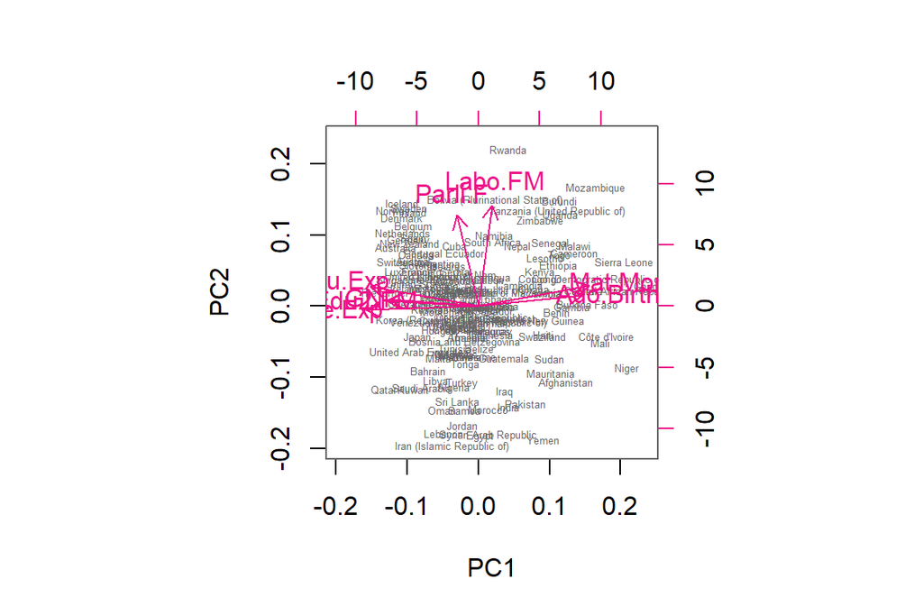

```r
# perform principal component analysis (with the SVD method)
pca_human5_std <- prcomp(human_std)

# draw a biplot of the principal component representation and the original variables
biplot(pca_human5_std, choices = 1:2, col = c("grey40", "deeppink2"), cex = c(0.4, 1))
```

Principal component analyses are presented above for raw data and standardized data. Results differed from each others, due to different scales used in outcomes. There were a lot of zero-length arrows in the raw-model, except GNI.

My personal interpretations of the first two principal component dimensions based on the biplot drawn for PCA on the standardized human data are Health and Equality.

## 5.3 Tea dataset

```r
library(dplyr)
library(tidyr)
library(ggplot2)
tea <- read.table("https://raw.githubusercontent.com/KimmoVehkalahti/Helsinki-Open-Data-Science/master/datasets/tea.csv", sep = ",", header = T)

#structure of the data
colnames(tea)
```

```
##  [1] "breakfast"        "tea.time"         "evening"          "lunch"
##  [5] "dinner"           "always"           "home"             "work"
##  [9] "tearoom"          "friends"          "resto"            "pub"
## [13] "Tea"              "How"              "sugar"            "how"
## [17] "where"            "price"            "age"              "sex"
## [21] "SPC"              "Sport"            "age_Q"            "frequency"
## [25] "escape.exoticism" "spirituality"     "healthy"          "diuretic"
## [29] "friendliness"     "iron.absorption"  "feminine"         "sophisticated"
## [33] "slimming"         "exciting"         "relaxing"         "effect.on.health"
```

```r
View(tea)

str(tea)
```

```
## 'data.frame':    300 obs. of  36 variables:
##  $ breakfast       : chr  "breakfast" "breakfast" "Not.breakfast" "Not.breakfast" ...
##  $ tea.time        : chr  "Not.tea time" "Not.tea time" "tea time" "Not.tea time" ...
##  $ evening         : chr  "Not.evening" "Not.evening" "evening" "Not.evening" ...
##  $ lunch           : chr  "Not.lunch" "Not.lunch" "Not.lunch" "Not.lunch" ...
##  $ dinner          : chr  "Not.dinner" "Not.dinner" "dinner" "dinner" ...
##  $ always          : chr  "Not.always" "Not.always" "Not.always" "Not.always" ...
##  $ home            : chr  "home" "home" "home" "home" ...
##  $ work            : chr  "Not.work" "Not.work" "work" "Not.work" ...
##  $ tearoom         : chr  "Not.tearoom" "Not.tearoom" "Not.tearoom" "Not.tearoom" ...
##  $ friends         : chr  "Not.friends" "Not.friends" "friends" "Not.friends" ...
##  $ resto           : chr  "Not.resto" "Not.resto" "resto" "Not.resto" ...
##  $ pub             : chr  "Not.pub" "Not.pub" "Not.pub" "Not.pub" ...
##  $ Tea             : chr  "black" "black" "Earl Grey" "Earl Grey" ...
##  $ How             : chr  "alone" "milk" "alone" "alone" ...
```

[output cut: 22 more lines]

```r
#convert outcomes to factors
tea$breakfast <- factor(tea$breakfast)
tea$tea.time <- factor(tea$tea.time)
tea$evening <- factor(tea$evening)
tea$lunch <- factor(tea$lunch)
tea$dinner <- factor(tea$dinner)
tea$always <- factor(tea$always)
tea$home <- factor(tea$home)
tea$work <- factor(tea$work)
tea$tearoom <- factor(tea$tearoom)
tea$friends <- factor(tea$friends)
tea$resto <- factor(tea$resto)
tea$pub <- factor(tea$pub)
tea$Tea <- factor(tea$Tea)
tea$How <- factor(tea$How)
tea$sugar <- factor(tea$sugar)
tea$how <- factor(tea$how)
tea$sugar <- factor(tea$sugar)
tea$where <- factor(tea$where)
tea$Tea <- factor(tea$Tea)
tea$price <- factor(tea$price)
tea$sex <- factor(tea$sex)
tea$SPC <- factor(tea$SPC)
tea$Sport <- factor(tea$Sport)
tea$age_Q <- factor(tea$age_Q)
tea$frequency <- factor(tea$frequency)
tea$escape.exoticism <- factor(tea$escape.exoticism)
tea$spirituality <- factor(tea$spirituality)
tea$healthy <- factor(tea$healthy)
tea$diuretic <- factor(tea$diuretic)
tea$friendliness <- factor(tea$friendliness)
tea$iron.absorption <- factor(tea$iron.absorption)
tea$feminine <- factor(tea$feminine)
tea$sophisticated <- factor(tea$sophisticated)
tea$slimming <- factor(tea$slimming)
tea$exciting <- factor(tea$exciting)
tea$relaxing <- factor(tea$relaxing)
tea$effect.on.health <- factor(tea$effect.on.health)


library(dplyr)
library(tidyr)

colnames(tea)
```

```
##  [1] "breakfast"        "tea.time"         "evening"          "lunch"
##  [5] "dinner"           "always"           "home"             "work"
##  [9] "tearoom"          "friends"          "resto"            "pub"
## [13] "Tea"              "How"              "sugar"            "how"
## [17] "where"            "price"            "age"              "sex"
## [21] "SPC"              "Sport"            "age_Q"            "frequency"
## [25] "escape.exoticism" "spirituality"     "healthy"          "diuretic"
## [29] "friendliness"     "iron.absorption"  "feminine"         "sophisticated"
## [33] "slimming"         "exciting"         "relaxing"         "effect.on.health"
```

```r
# column names to keep in the dataset
keep_columns <- c("tea.time","evening", "lunch","dinner","always","home","work", "tearoom","friends","resto","pub","Tea",
"How","sugar","how","where","price","sex","SPC","Sport","age_Q" ,"frequency"
,"escape.exoticism","spirituality","healthy","diuretic","friendliness","iron.absorption"
,"feminine","sophisticated","slimming","exciting","relaxing","effect.on.health")

# select the 'keep_columns' to create a new dataset
tea_time <- dplyr::select(tea, keep_columns)
# look at the summaries and structure of the data
summary(tea_time)
```

```
##          tea.time          evening          lunch            dinner
##  Not.tea time:131   evening    :103   lunch    : 44   dinner    : 21
##  tea time    :169   Not.evening:197   Not.lunch:256   Not.dinner:279
##
##
##
##
##
##         always          home           work            tearoom
##  always    :103   home    :291   Not.work:213   Not.tearoom:242
##  Not.always:197   Not.home:  9   work    : 87   tearoom    : 58
##
##
##
##
##
##         friends          resto          pub             Tea         How
##  friends    :196   Not.resto:221   Not.pub:237   black    : 74   alone:195
##  Not.friends:104   resto    : 79   pub    : 63   Earl Grey:193   lemon: 33
##                                                  green    : 33   milk : 63
##                                                                  other:  9
##
##
##
##       sugar                     how                       where
##  No.sugar:155   tea bag           :170   chain store         :192
##  sugar   :145   tea bag+unpackaged: 94   chain store+tea shop: 78
##                 unpackaged        : 36   tea shop            : 30
##
##
##
##
##              price     sex               SPC               Sport       age_Q
##  p_branded      : 95   F:178   employee    :59   Not.sportsman:121   +60  :38
##  p_cheap        :  7   M:122   middle      :40   sportsman    :179   15-24:92
##  p_private label: 21           non-worker  :64                       25-34:69
##  p_unknown      : 12           other worker:20                       35-44:40
##  p_upscale      : 53           senior      :35                       45-59:61
##  p_variable     :112           student     :70
##                                workman     :12
```

[output cut: 25 more lines]

```
##  No.slimming:255   exciting   :116   No.relaxing:113
##  slimming   : 45   No.exciting:184   relaxing   :187
##
##
##
##
##
##             effect.on.health
##  effect on health   : 66
##  No.effect on health:234
##
##
##
##
##
```

```r
str(tea_time)
```

```
## 'data.frame':    300 obs. of  34 variables:
##  $ tea.time        : Factor w/ 2 levels "Not.tea time",..: 1 1 2 1 1 1 2 2 2 1 ...
##  $ evening         : Factor w/ 2 levels "evening","Not.evening": 2 2 1 2 1 2 2 1 2 1 ...
##  $ lunch           : Factor w/ 2 levels "lunch","Not.lunch": 2 2 2 2 2 2 2 2 2 2 ...
##  $ dinner          : Factor w/ 2 levels "dinner","Not.dinner": 2 2 1 1 2 1 2 2 2 2 ...
##  $ always          : Factor w/ 2 levels "always","Not.always": 2 2 2 2 1 2 2 2 2 2 ...
##  $ home            : Factor w/ 2 levels "home","Not.home": 1 1 1 1 1 1 1 1 1 1 ...
##  $ work            : Factor w/ 2 levels "Not.work","work": 1 1 2 1 1 1 1 1 1 1 ...
##  $ tearoom         : Factor w/ 2 levels "Not.tearoom",..: 1 1 1 1 1 1 1 1 1 2 ...
##  $ friends         : Factor w/ 2 levels "friends","Not.friends": 2 2 1 2 2 2 1 2 2 2 ...
##  $ resto           : Factor w/ 2 levels "Not.resto","resto": 1 1 2 1 1 1 1 1 1 1 ...
##  $ pub             : Factor w/ 2 levels "Not.pub","pub": 1 1 1 1 1 1 1 1 1 1 ...
##  $ Tea             : Factor w/ 3 levels "black","Earl Grey",..: 1 1 2 2 2 2 2 1 2 1 ...
##  $ How             : Factor w/ 4 levels "alone","lemon",..: 1 3 1 1 1 1 1 3 3 1 ...
##  $ sugar           : Factor w/ 2 levels "No.sugar","sugar": 2 1 1 2 1 1 1 1 1 1 ...
```

[output cut: 20 more lines]

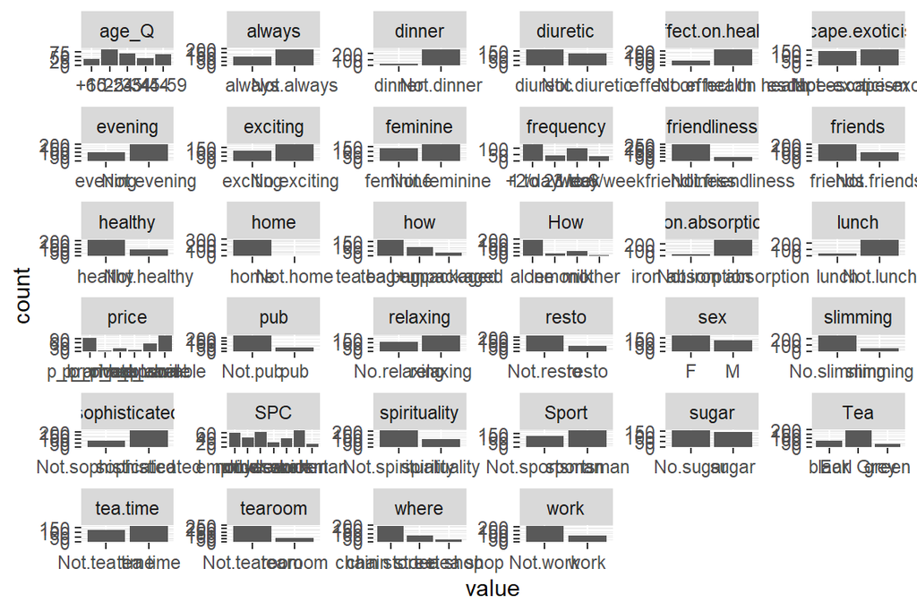

```r
# visualize the dataset
library(ggplot2)
pivot_longer(tea_time, cols = everything()) %>%
  ggplot(aes(value), theme(axis.text.x = element_text(angle = 120, hjust = 1, size = 3))) + facet_wrap("name", scales = "free") + geom_bar()
```

```r
#multiple correspondence analysis
library(FactoMineR)
```

```r
mca <- MCA(tea_time, graph = FALSE)

# summary of the model
summary(mca)
```

```
##
## Call:
## MCA(X = tea_time, graph = FALSE)
##
##
## Eigenvalues
##                        Dim.1   Dim.2   Dim.3   Dim.4   Dim.5   Dim.6   Dim.7
## Variance               0.092   0.084   0.072   0.060   0.057   0.055   0.050
## % of var.              5.913   5.392   4.629   3.881   3.672   3.502   3.188
## Cumulative % of var.   5.913  11.305  15.934  19.815  23.488  26.989  30.177
##                        Dim.8   Dim.9  Dim.10  Dim.11  Dim.12  Dim.13  Dim.14
## Variance               0.049   0.048   0.045   0.042   0.042   0.039   0.038
## % of var.              3.138   3.050   2.885   2.675   2.672   2.491   2.424
## Cumulative % of var.  33.315  36.365  39.251  41.926  44.598  47.089  49.513
##                       Dim.15  Dim.16  Dim.17  Dim.18  Dim.19  Dim.20  Dim.21
## Variance               0.036   0.036   0.034   0.032   0.032   0.031   0.030
## % of var.              2.320   2.305   2.173   2.077   2.049   2.016   1.944
## Cumulative % of var.  51.833  54.138  56.311  58.387  60.436  62.453  64.397
##                       Dim.22  Dim.23  Dim.24  Dim.25  Dim.26  Dim.27  Dim.28
## Variance               0.029   0.027   0.026   0.026   0.025   0.024   0.024
## % of var.              1.880   1.761   1.692   1.669   1.624   1.553   1.544
## Cumulative % of var.  66.276  68.038  69.730  71.399  73.023  74.577  76.120
##                       Dim.29  Dim.30  Dim.31  Dim.32  Dim.33  Dim.34  Dim.35
## Variance               0.023   0.022   0.022   0.021   0.020   0.019   0.019
## % of var.              1.456   1.426   1.404   1.339   1.264   1.246   1.221
## Cumulative % of var.  77.576  79.002  80.406  81.745  83.009  84.255  85.476
##                       Dim.36  Dim.37  Dim.38  Dim.39  Dim.40  Dim.41  Dim.42
## Variance               0.017   0.017   0.017   0.016   0.016   0.015   0.015
## % of var.              1.120   1.112   1.078   1.028   1.005   0.968   0.939
## Cumulative % of var.  86.596  87.708  88.786  89.814  90.819  91.786  92.725
##                       Dim.43  Dim.44  Dim.45  Dim.46  Dim.47  Dim.48  Dim.49
## Variance               0.013   0.013   0.012   0.012   0.011   0.010   0.010
## % of var.              0.866   0.837   0.802   0.739   0.697   0.674   0.666
## Cumulative % of var.  93.590  94.427  95.229  95.968  96.666  97.339  98.005
##                       Dim.50  Dim.51  Dim.52  Dim.53
## Variance               0.009   0.008   0.007   0.006
## % of var.              0.603   0.531   0.458   0.403
## Cumulative % of var.  98.608  99.139  99.597 100.000
##
## Individuals (the 10 first)
```

[output cut: 44 more lines]

```
## always        0.095  0.126  0.005  1.186 |
## Not.always   -0.050  0.066  0.005 -1.186 |
##
## Categorical variables (eta2)
##                Dim.1 Dim.2 Dim.3
## tea.time     | 0.236 0.000 0.003 |
## evening      | 0.046 0.085 0.055 |
## lunch        | 0.060 0.028 0.011 |
## dinner       | 0.082 0.000 0.042 |
## always       | 0.061 0.034 0.005 |
## home         | 0.013 0.002 0.027 |
## work         | 0.071 0.020 0.027 |
## tearoom      | 0.326 0.021 0.027 |
## friends      | 0.201 0.058 0.024 |
## resto        | 0.155 0.007 0.030 |
```

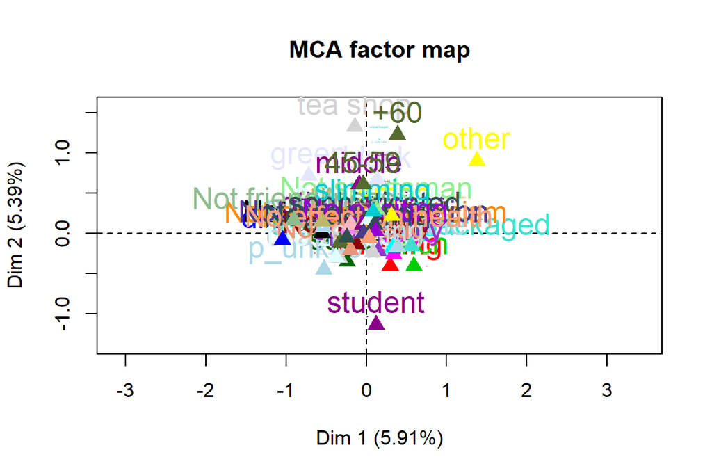

```r
# visualize MCA
plot(mca, invisible=c("ind"), graph.type = "classic", habillage = "quali", cex = c(1.5, 0.2))
```

```r
#multiple correspondence analysis for the selcected outcomes
library(FactoMineR)
mca2 <- MCA(tea_time[1:13], graph = FALSE)

# summary of the model
summary(mca2)
```

```
##
## Call:
## MCA(X = tea_time[1:13], graph = FALSE)
##
##
## Eigenvalues
##                        Dim.1   Dim.2   Dim.3   Dim.4   Dim.5   Dim.6   Dim.7
## Variance               0.168   0.109   0.098   0.092   0.087   0.083   0.078
## % of var.             13.631   8.816   7.986   7.498   7.098   6.703   6.332
## Cumulative % of var.  13.631  22.446  30.432  37.930  45.028  51.731  58.063
##                        Dim.8   Dim.9  Dim.10  Dim.11  Dim.12  Dim.13  Dim.14
## Variance               0.077   0.069   0.065   0.060   0.058   0.052   0.050
## % of var.              6.266   5.597   5.318   4.899   4.696   4.212   4.068
## Cumulative % of var.  64.329  69.926  75.244  80.143  84.839  89.051  93.118
##                       Dim.15  Dim.16
## Variance               0.044   0.041
## % of var.              3.544   3.338
## Cumulative % of var.  96.662 100.000
##
## Individuals (the 10 first)
##                 Dim.1    ctr   cos2    Dim.2    ctr   cos2    Dim.3    ctr
## 1            | -0.582  0.674  0.471 |  0.311  0.298  0.134 | -0.080  0.022
## 2            | -0.538  0.574  0.298 |  0.418  0.537  0.181 | -0.359  0.438
## 3            |  0.209  0.087  0.024 |  0.014  0.001  0.000 |  0.471  0.751
## 4            | -0.750  1.118  0.364 |  0.048  0.007  0.001 |  0.583  1.151
## 5            | -0.297  0.175  0.119 | -0.289  0.257  0.113 |  0.080  0.022
## 6            | -0.750  1.118  0.364 |  0.048  0.007  0.001 |  0.583  1.151
## 7            | -0.140  0.039  0.051 | -0.048  0.007  0.006 | -0.062  0.013
## 8            | -0.220  0.096  0.047 |  0.448  0.617  0.194 | -0.582  1.148
## 9            | -0.314  0.195  0.134 |  0.144  0.064  0.028 | -0.365  0.452
## 10           | -0.191  0.073  0.032 |  0.426  0.556  0.160 | -0.066  0.015
##                cos2
## 1             0.009 |
## 2             0.133 |
## 3             0.120 |
## 4             0.220 |
## 5             0.009 |
## 6             0.220 |
## 7             0.010 |
## 8             0.327 |
```

[output cut: 24 more lines]

```
## always        0.203  1.107  0.022  2.537 |
## Not.always   -0.106  0.579  0.022 -2.537 |
##
## Categorical variables (eta2)
##                Dim.1 Dim.2 Dim.3
## tea.time     | 0.240 0.043 0.100 |
## evening      | 0.111 0.019 0.016 |
## lunch        | 0.097 0.068 0.182 |
## dinner       | 0.078 0.014 0.283 |
## always       | 0.085 0.107 0.022 |
## home         | 0.000 0.060 0.083 |
## work         | 0.189 0.029 0.001 |
## tearoom      | 0.296 0.095 0.017 |
## friends      | 0.307 0.030 0.002 |
## resto        | 0.325 0.042 0.016 |
```

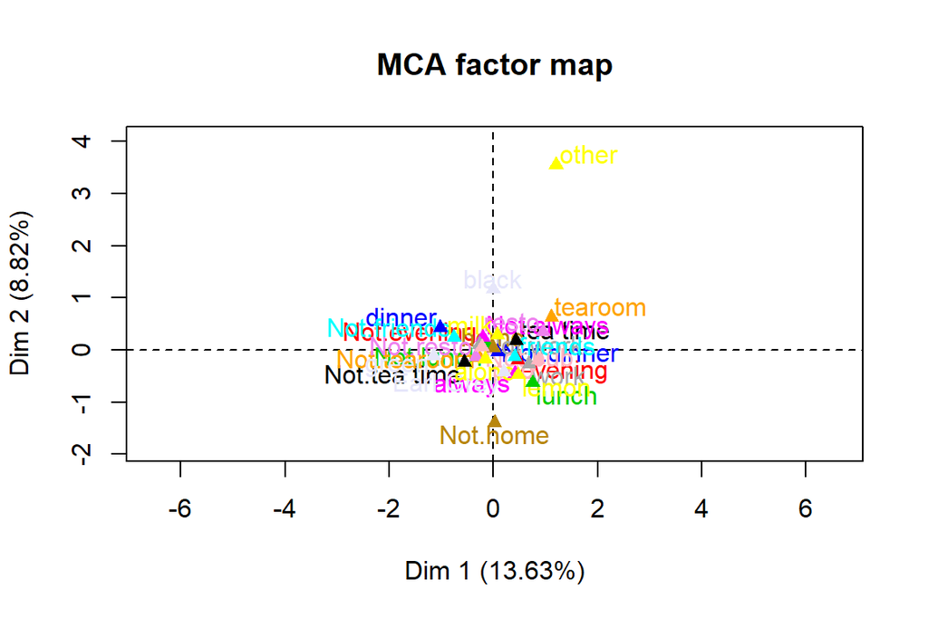

```r
# visualize MCA
plot(mca2, invisible=c("ind"), graph.type = "classic", habillage = "quali")
```

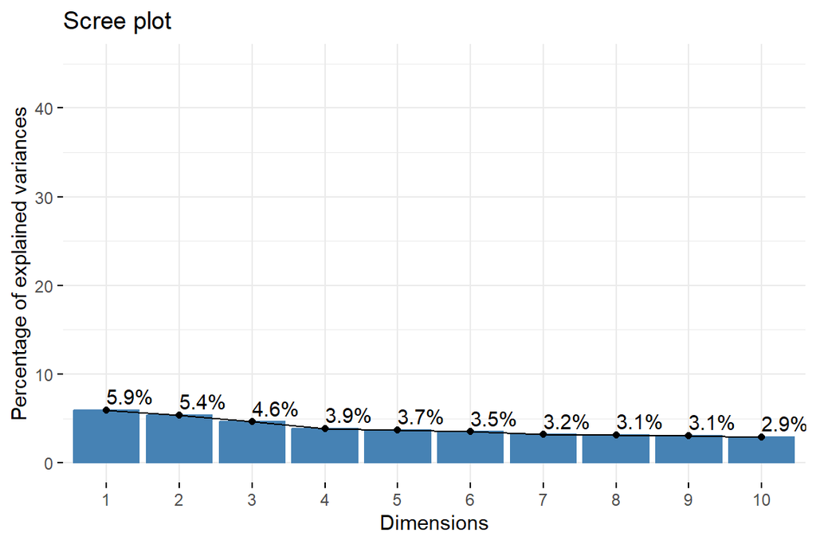

```r
install.packages("ggplot2")
library(ggplot2)
library(factoextra)
#to visualize the percentages of inertia explained by each MCA dimensions,
fviz_screeplot(mca, addlabels = TRUE, ylim = c(0, 45))
```

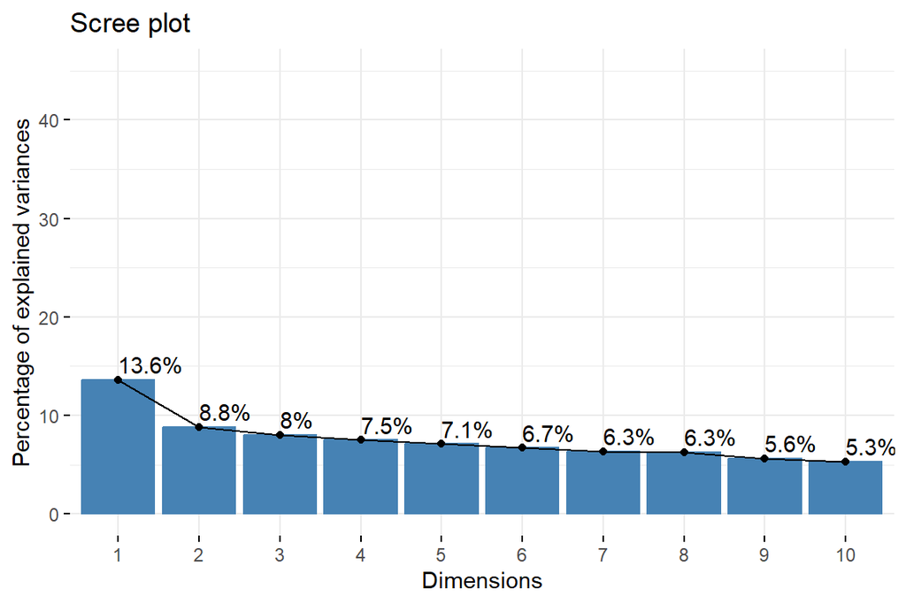

```r
fviz_screeplot(mca2, addlabels = TRUE, ylim = c(0, 45))
```

The Multiple Correspondence Analysis (MCA) on the total tea data (mca) and for the selected variables are presented above as well as biplots and plots to visualize the percentages of inertia explained by each MCA dimensions.

# Assignment 6

```r
#read the data sets from folder

library(dplyr)
library(tidyr)
library(tidyverse)

RATSL <- read.csv("~/IODS-project/RATSL.csv")
stringsAsFactors = FALSE
RATS <- read.csv("~/IODS-project/RATS.csv")
stringsAsFactors = FALSE
BPRSL <- read.csv("~/IODS-project/BPRSL.csv")
stringsAsFactors = FALSE
BPRS <- read.csv("~/IODS-project/BPRS.csv")
stringsAsFactors = FALSE


#Convert the categorical variables of both data sets to factors (again)
BPRS$treatment <- factor(BPRS$treatment)
BPRS$subject <- factor(BPRS$subject)
BPRSL$treatment <- factor(BPRSL$treatment)
BPRSL$subject <- factor(BPRSL$subject)



RATS$ID <- factor(RATS$ID)
RATS$Group <- factor(RATS$Group)
RATSL$ID <- factor(RATSL$ID)
RATSL$Group <- factor(RATSL$Group)

#names
names(BPRS)
```

```
##  [1] "treatment" "subject"   "week0"     "week1"     "week2"     "week3"
##  [7] "week4"     "week5"     "week6"     "week7"     "week8"
```

```r
names(RATS)
```

```
##  [1] "ID"    "Group" "WD1"   "WD8"   "WD15"  "WD22"  "WD29"  "WD36"  "WD43"
## [10] "WD44"  "WD50"  "WD57"  "WD64"
```

```r
names(BPRSL)
```

```
## [1] "treatment" "subject"   "weeks"     "bprs"      "week"
```

```r
names(RATSL)
```

```
## [1] "ID"     "Group"  "WD"     "Weight" "Time"
```

```r
#structure
str(BPRS)
```

```
## 'data.frame':    40 obs. of  11 variables:
##  $ treatment: Factor w/ 2 levels "1","2": 1 1 1 1 1 1 1 1 1 1 ...
##  $ subject  : Factor w/ 20 levels "1","2","3","4",..: 1 2 3 4 5 6 7 8 9 10 ...
##  $ week0    : int  42 58 54 55 72 48 71 30 41 57 ...
##  $ week1    : int  36 68 55 77 75 43 61 36 43 51 ...
##  $ week2    : int  36 61 41 49 72 41 47 38 39 51 ...
##  $ week3    : int  43 55 38 54 65 38 30 38 35 55 ...
##  $ week4    : int  41 43 43 56 50 36 27 31 28 53 ...
##  $ week5    : int  40 34 28 50 39 29 40 26 22 43 ...
##  $ week6    : int  38 28 29 47 32 33 30 26 20 43 ...
##  $ week7    : int  47 28 25 42 38 27 31 25 23 39 ...
##  $ week8    : int  51 28 24 46 32 25 31 24 21 32 ...
```

```r
str(RATS)
```

```
## 'data.frame':    16 obs. of  13 variables:
##  $ ID   : Factor w/ 16 levels "1","2","3","4",..: 1 2 3 4 5 6 7 8 9 10 ...
##  $ Group: Factor w/ 3 levels "1","2","3": 1 1 1 1 1 1 1 1 2 2 ...
##  $ WD1  : int  240 225 245 260 255 260 275 245 410 405 ...
##  $ WD8  : int  250 230 250 255 260 265 275 255 415 420 ...
##  $ WD15 : int  255 230 250 255 255 270 260 260 425 430 ...
##  $ WD22 : int  260 232 255 265 270 275 270 268 428 440 ...
##  $ WD29 : int  262 240 262 265 270 275 273 270 438 448 ...
##  $ WD36 : int  258 240 265 268 273 277 274 265 443 460 ...
##  $ WD43 : int  266 243 267 270 274 278 276 265 442 458 ...
##  $ WD44 : int  266 244 267 272 273 278 271 267 446 464 ...
##  $ WD50 : int  265 238 264 274 276 284 282 273 456 475 ...
##  $ WD57 : int  272 247 268 273 278 279 281 274 468 484 ...
##  $ WD64 : int  278 245 269 275 280 281 284 278 478 496 ...
```

```r
str(BPRSL)
```

```
## 'data.frame':    360 obs. of  5 variables:
##  $ treatment: Factor w/ 2 levels "1","2": 1 1 1 1 1 1 1 1 1 1 ...
##  $ subject  : Factor w/ 20 levels "1","2","3","4",..: 1 2 3 4 5 6 7 8 9 10 ...
##  $ weeks    : chr  "week0" "week0" "week0" "week0" ...
##  $ bprs     : int  42 58 54 55 72 48 71 30 41 57 ...
##  $ week     : int  0 0 0 0 0 0 0 0 0 0 ...
```

```r
str(RATSL)
```

```
## 'data.frame':    176 obs. of  5 variables:
##  $ ID    : Factor w/ 16 levels "1","2","3","4",..: 1 2 3 4 5 6 7 8 9 10 ...
##  $ Group : Factor w/ 3 levels "1","2","3": 1 1 1 1 1 1 1 1 2 2 ...
##  $ WD    : chr  "WD1" "WD1" "WD1" "WD1" ...
##  $ Weight: int  240 225 245 260 255 260 275 245 410 405 ...
##  $ Time  : int  1 1 1 1 1 1 1 1 1 1 ...
```

```r
#summary
summary(BPRS)
```

```
##  treatment    subject       week0           week1           week2
##  1:20      1      : 2   Min.   :24.00   Min.   :23.00   Min.   :26.0
##  2:20      2      : 2   1st Qu.:38.00   1st Qu.:35.00   1st Qu.:32.0
##            3      : 2   Median :46.00   Median :41.00   Median :38.0
##            4      : 2   Mean   :48.00   Mean   :46.33   Mean   :41.7
##            5      : 2   3rd Qu.:58.25   3rd Qu.:54.25   3rd Qu.:49.0
##            6      : 2   Max.   :78.00   Max.   :95.00   Max.   :75.0
##            (Other):28
##      week3           week4           week5           week6           week7
##  Min.   :24.00   Min.   :20.00   Min.   :20.00   Min.   :19.00   Min.   :18.0
##  1st Qu.:29.75   1st Qu.:28.00   1st Qu.:26.00   1st Qu.:22.75   1st Qu.:23.0
##  Median :36.50   Median :34.50   Median :30.50   Median :28.50   Median :30.0
##  Mean   :39.15   Mean   :36.35   Mean   :32.55   Mean   :31.23   Mean   :32.2
##  3rd Qu.:44.50   3rd Qu.:43.00   3rd Qu.:38.00   3rd Qu.:37.00   3rd Qu.:38.0
##  Max.   :76.00   Max.   :66.00   Max.   :64.00   Max.   :64.00   Max.   :62.0
##
##      week8
##  Min.   :20.00
##  1st Qu.:22.75
##  Median :28.00
##  Mean   :31.43
##  3rd Qu.:35.25
##  Max.   :75.00
##
```

```r
summary(RATS)
```

```
##        ID     Group      WD1             WD8             WD15
##  1      : 1   1:8   Min.   :225.0   Min.   :230.0   Min.   :230.0
##  2      : 1   2:4   1st Qu.:252.5   1st Qu.:255.0   1st Qu.:255.0
##  3      : 1   3:4   Median :340.0   Median :345.0   Median :347.5
##  4      : 1         Mean   :365.9   Mean   :369.1   Mean   :372.5
##  5      : 1         3rd Qu.:480.0   3rd Qu.:476.2   3rd Qu.:486.2
##  6      : 1         Max.   :555.0   Max.   :560.0   Max.   :565.0
##  (Other):10
##       WD22            WD29            WD36            WD43
##  Min.   :232.0   Min.   :240.0   Min.   :240.0   Min.   :243.0
##  1st Qu.:267.2   1st Qu.:268.8   1st Qu.:267.2   1st Qu.:269.2
##  Median :351.5   Median :356.5   Median :360.0   Median :360.0
##  Mean   :379.2   Mean   :383.9   Mean   :387.0   Mean   :386.0
##  3rd Qu.:492.5   3rd Qu.:497.8   3rd Qu.:504.2   3rd Qu.:501.0
##  Max.   :580.0   Max.   :590.0   Max.   :597.0   Max.   :595.0
##
##       WD44            WD50            WD57            WD64
##  Min.   :244.0   Min.   :238.0   Min.   :247.0   Min.   :245.0
##  1st Qu.:270.0   1st Qu.:273.8   1st Qu.:273.8   1st Qu.:278.0
##  Median :362.0   Median :370.0   Median :373.5   Median :378.0
##  Mean   :388.3   Mean   :394.6   Mean   :398.6   Mean   :404.1
##  3rd Qu.:510.5   3rd Qu.:516.0   3rd Qu.:524.5   3rd Qu.:530.8
##  Max.   :595.0   Max.   :612.0   Max.   :618.0   Max.   :628.0
##
```

```r
summary(BPRSL)
```

```
##  treatment    subject       weeks                bprs            week
##  1:180     1      : 18   Length:360         Min.   :18.00   Min.   :0
##  2:180     2      : 18   Class :character   1st Qu.:27.00   1st Qu.:2
##            3      : 18   Mode  :character   Median :35.00   Median :4
##            4      : 18                      Mean   :37.66   Mean   :4
##            5      : 18                      3rd Qu.:43.00   3rd Qu.:6
##            6      : 18                      Max.   :95.00   Max.   :8
##            (Other):252
```

```r
summary(RATSL)
```

```
##        ID      Group       WD                Weight           Time
##  1      : 11   1:88   Length:176         Min.   :225.0   Min.   : 1.00
##  2      : 11   2:44   Class :character   1st Qu.:267.0   1st Qu.:15.00
##  3      : 11   3:44   Mode  :character   Median :344.5   Median :36.00
##  4      : 11                             Mean   :384.5   Mean   :33.55
##  5      : 11                             3rd Qu.:511.2   3rd Qu.:50.00
##  6      : 11                             Max.   :628.0   Max.   :64.00
##  (Other):110
```

```r
View(RATS)
View(BPRS)
View(RATSL)
View(BPRSL)
```